# Lab 4: The Multi-Layer Perceptron

### Group Mode

Eric Houtman,

Rick Lattin,

Kellen Long

## Load, Split, and Balance

```python
#load the acs2017_census_tract_data csv into memory and save it in a dataframe

import pandas as pd
import numpy as np
import matplotlib.pyplot as plt
from sklearn.datasets import load_digits
from sklearn.metrics import accuracy_score
from sklearn.preprocessing import StandardScaler
from scipy.special import expit
import sys

census_data = pd.read_csv('acs2017_census_tract_data.csv')
census_data.head()
```

|  | TractId | State | County | TotalPop | Men | Women | Hispanic | White | Black | Native | ... | Walk | OtherTransp | WorkAtHome | MeanCommute | Employed | PrivateWork | PublicWork | SelfEmployed | FamilyWork | Unemployment |
| --- | --- | --- | --- | --- | --- | --- | --- | --- | --- | --- | --- | --- | --- | --- | --- | --- | --- | --- | --- | --- | --- |
| 0 | 1001020100 | Alabama | Autauga County | 1845 | 899 | 946 | 2.4 | 86.3 | 5.2 | 0.0 | ... | 0.5 | 0.0 | 2.1 | 24.5 | 881 | 74.2 | 21.2 | 4.5 | 0.0 | 4.6 |
| 1 | 1001020200 | Alabama | Autauga County | 2172 | 1167 | 1005 | 1.1 | 41.6 | 54.5 | 0.0 | ... | 0.0 | 0.5 | 0.0 | 22.2 | 852 | 75.9 | 15.0 | 9.0 | 0.0 | 3.4 |
| 2 | 1001020300 | Alabama | Autauga County | 3385 | 1533 | 1852 | 8.0 | 61.4 | 26.5 | 0.6 | ... | 1.0 | 0.8 | 1.5 | 23.1 | 1482 | 73.3 | 21.1 | 4.8 | 0.7 | 4.7 |
| 3 | 1001020400 | Alabama | Autauga County | 4267 | 2001 | 2266 | 9.6 | 80.3 | 7.1 | 0.5 | ... | 1.5 | 2.9 | 2.1 | 25.9 | 1849 | 75.8 | 19.7 | 4.5 | 0.0 | 6.1 |
| 4 | 1001020500 | Alabama | Autauga County | 9965 | 5054 | 4911 | 0.9 | 77.5 | 16.4 | 0.0 | ... | 0.8 | 0.3 | 0.7 | 21.0 | 4787 | 71.4 | 24.1 | 4.5 | 0.0 | 2.3 |

5 rows × 37 columns

#### Checking and removing nulls and NaNs

```python
#check for missing values
census_data.isnull().sum()

#remove the rows with missing values
census_data = census_data.dropna()

#check for missing values again
census_data.isnull().sum()
```

```
TractId             0
State               0
County              0
TotalPop            0
Men                 0
Women               0
Hispanic            0
White               0
Black               0
Native              0
Asian               0
Pacific             0
VotingAgeCitizen    0
Income              0
IncomeErr           0
IncomePerCap        0
IncomePerCapErr     0
Poverty             0
ChildPoverty        0
Professional        0
Service             0
Office              0
Construction        0
Production          0
Drive               0
Carpool             0
Transit             0
Walk                0
OtherTransp         0
WorkAtHome          0
MeanCommute         0
Employed            0
PrivateWork         0
PublicWork          0
SelfEmployed        0
FamilyWork          0
Unemployment        0
dtype: int64
```

```python
#encode the string columns to integer values
from sklearn.preprocessing import LabelEncoder
le = LabelEncoder()
census_data['State'] = le.fit_transform(census_data['State'])
census_data['County'] = le.fit_transform(census_data['County'])

#check the data types of the columns
census_data.dtypes
```

```
TractId               int64
State                 int64
County                int64
TotalPop              int64
Men                   int64
Women                 int64
Hispanic            float64
White               float64
Black               float64
Native              float64
Asian               float64
Pacific             float64
VotingAgeCitizen      int64
Income              float64
IncomeErr           float64
IncomePerCap        float64
IncomePerCapErr     float64
Poverty             float64
ChildPoverty        float64
Professional        float64
Service             float64
Office              float64
Construction        float64
Production          float64
Drive               float64
Carpool             float64
Transit             float64
Walk                float64
OtherTransp         float64
WorkAtHome          float64
MeanCommute         float64
Employed              int64
PrivateWork         float64
PublicWork          float64
SelfEmployed        float64
FamilyWork          float64
Unemployment        float64
dtype: object
```

```python
#check for not a number values
census_data.isna().sum()
```

```
TractId             0
State               0
County              0
TotalPop            0
Men                 0
Women               0
Hispanic            0
White               0
Black               0
Native              0
Asian               0
Pacific             0
VotingAgeCitizen    0
Income              0
IncomeErr           0
IncomePerCap        0
IncomePerCapErr     0
Poverty             0
ChildPoverty        0
Professional        0
Service             0
Office              0
Construction        0
Production          0
Drive               0
Carpool             0
Transit             0
Walk                0
OtherTransp         0
WorkAtHome          0
MeanCommute         0
Employed            0
PrivateWork         0
PublicWork          0
SelfEmployed        0
FamilyWork          0
Unemployment        0
dtype: int64
```

```python
#remove the county variable if needed (DISCUSS WHY WE ARE DOING THIS)
#census_data = census_data.drop(['County'], axis=1)
```

We decided to include the County column, as for larger states such as Texas, there would be no way to gather accurate data across the whole state just based on the mean of the entire state. By including county, we are able to get a more accurate representation of the state as a whole, with its different areas and counties explaining why the state average would be the way it is.

#### Balancing the Data

For this assignment, we decided to split the data by separating the child poverty table into quartiles, then separating the data based on that. We also decided to balance the data before splitting the data, as we believed it would be beneficial to be testing the data based on the splits, as this would give us better results, albeit a little more general.

```python
#calculate quantile thresholds
quantile_thresholds = np.percentile(census_data['ChildPoverty'], [25, 50, 75])
print(quantile_thresholds)

#quantize the ChildPoverty variable
census_data['ChildPoverty'] = np.digitize(census_data['ChildPoverty'], quantile_thresholds)

#check the quantization
census_data['ChildPoverty'].value_counts()
```

```
[ 6.2 16.3 31.6]
```

```
3    18265
1    18220
2    18214
0    18019
Name: ChildPoverty, dtype: int64
```

```python
#check for not a number values
census_data.isna().sum()
```

```
TractId             0
State               0
County              0
TotalPop            0
Men                 0
Women               0
Hispanic            0
White               0
Black               0
Native              0
Asian               0
Pacific             0
VotingAgeCitizen    0
Income              0
IncomeErr           0
IncomePerCap        0
IncomePerCapErr     0
Poverty             0
ChildPoverty        0
Professional        0
Service             0
Office              0
Construction        0
Production          0
Drive               0
Carpool             0
Transit             0
Walk                0
OtherTransp         0
WorkAtHome          0
MeanCommute         0
Employed            0
PrivateWork         0
PublicWork          0
SelfEmployed        0
FamilyWork          0
Unemployment        0
dtype: int64
```

Here, we split the data into the 80/20 testing and training splits.

```python
#split the data into training and testing sets using the quantized ChildPoverty variable as the target
from sklearn.model_selection import train_test_split
X = census_data.drop(['ChildPoverty'], axis=1)
y = census_data['ChildPoverty']
X_train, X_test, y_train, y_test = train_test_split(X, y, test_size=0.2, random_state=0)

#covert the training and testing sets into numpy arrays
X_train = X_train.values
X_test = X_test.values
y_train = y_train.values
y_test = y_test.values

#check the shapes of the training and testing sets
print(X_train.shape)
print(X_test.shape)
print(y_train.shape)
print(y_test.shape)
```

```
(58174, 36)
(14544, 36)
(58174,)
(14544,)
```

```python
#check the data types of the columns
census_data.dtypes
```

```
TractId               int64
State                 int64
County                int64
TotalPop              int64
Men                   int64
Women                 int64
Hispanic            float64
White               float64
Black               float64
Native              float64
Asian               float64
Pacific             float64
VotingAgeCitizen      int64
Income              float64
IncomeErr           float64
IncomePerCap        float64
IncomePerCapErr     float64
Poverty             float64
ChildPoverty          int64
Professional        float64
Service             float64
Office              float64
Construction        float64
Production          float64
Drive               float64
Carpool             float64
Transit             float64
Walk                float64
OtherTransp         float64
WorkAtHome          float64
MeanCommute         float64
Employed              int64
PrivateWork         float64
PublicWork          float64
SelfEmployed        float64
FamilyWork          float64
Unemployment        float64
dtype: object
```

```python
#print some information about the training and testing sets
print('X_train shape:', X_train.shape)
print('y_train shape:', y_train.shape)
print('X_test shape:', X_test.shape)
print('y_test shape:', y_test.shape)
```

```
X_train shape: (58174, 36)
y_train shape: (58174,)
X_test shape: (14544, 36)
y_test shape: (14544,)
```

## Pre-processing and Initial Modeling

### Two Layer Perceptron using Vectorized Backpropogation, Cross Entropy Loss, Glorot Initialization, and Minibatching

```python
class TLPVectorizedMiniBatchCEVectorized(object):
    def __init__(self, n_hidden=30,
                 C=0.0, epochs=100, eta=0.001,
                 alpha=0.0, decrease_const=0.0,
                 shuffle=True, minibatches=1, random_state=None):
        np.random.seed(random_state)
        self.n_hidden = n_hidden
        self.l2_C = C
        self.epochs = epochs
        self.eta = eta
        self.alpha = alpha
        self.decrease_const = decrease_const
        self.shuffle = shuffle
        self.minibatches = minibatches

    @staticmethod
    def _encode_labels(y):
        onehot = pd.get_dummies(y).values.T

        return onehot

    def _initialize_weights(self):
        init_bound = 4*np.sqrt(6. / (self.n_hidden + self.n_features_))
        W1 = np.random.uniform(-init_bound, init_bound,(self.n_hidden, self.n_features_))

        # reduce the final layer magnitude in order to balance the size of the gradients
        # between
        init_bound = 4*np.sqrt(6 / (self.n_output_ + self.n_hidden))
        W2 = np.random.uniform(-init_bound, init_bound,(self.n_output_, self.n_hidden))

        b1 = np.zeros((self.n_hidden, 1))
        b2 = np.zeros((self.n_output_, 1))

        return W1, W2, b1, b2

    @staticmethod
    def _sigmoid(z):
        return expit(z)


    @staticmethod
    def _L2_reg(lambda_, W1, W2):
        # only compute for non-bias terms
        return (lambda_) * np.sqrt(np.mean(W1 ** 2) + np.mean(W2 ** 2))

    def _cost(self,A3,Y_enc,W1,W2):
        cost = -np.mean(np.nan_to_num((Y_enc*np.log(A3)+(1-Y_enc)*np.log(1-A3))))
        L2_term = self._L2_reg(self.l2_C, W1, W2)
        return cost + L2_term

    def _feedforward(self, X, W1, W2, b1, b2):
        A1 = X.T
        Z1 = W1 @ A1 + b1
        A2 = self._sigmoid(Z1)
        Z2 = W2 @ A2 + b2
        A3 = self._sigmoid(Z2)
        return A1, Z1, A2, Z2, A3

    def _get_gradient(self, A1, A2, A3, Z1, Z2, Y_enc, W1, W2):
        # vectorized backpropagation
        V2 = (A3-Y_enc) # <- this is only line that changed
        V1 = A2*(1-A2)*(W2.T @ V2)

        gradW2 = V2 @ A2.T
        gradW1 = V1 @ A1.T

        gradb2 = np.sum(V2, axis=1).reshape((-1,1))
        gradb1 = np.sum(V1, axis=1).reshape((-1,1))

        # regularize weights that are not bias terms
        gradW1 += W1 * self.l2_C
        gradW2 += W2 * self.l2_C

        return gradW1, gradW2, gradb1, gradb2

    def predict(self, X):
        _, _, _, _, A3 = self._feedforward(X, self.W1, self.W2, self.b1, self.b2)
        y_pred = np.argmax(A3, axis=0)
        return y_pred


    def fit(self, X, y, print_progress=0):
        X_data, y_data = X.copy(), y.copy()
        Y_enc = self._encode_labels(y)

        # init weights and setup matrices
        self.n_features_ = X_data.shape[1]
        self.n_output_ = Y_enc.shape[0]
        self.W1, self.W2, self.b1, self.b2 = self._initialize_weights()

        # start momentum at zero for previous updates
        rho_W1_prev = np.zeros(self.W1.shape) # for momentum
        rho_W2_prev = np.zeros(self.W2.shape) # for momentum

        self.cost_ = []
        for k in range(self.epochs):

            # adaptive learning rate
            eta = self.eta**(1+self.decrease_const*k)# decreasing learning rate
            eta = max(eta,self.eta/1000)
            # there are many forms of adaptive learning rates out there!

            if print_progress>0 and (k+1)%print_progress==0:
                sys.stderr.write('\rEpoch: %d/%d' % (k+1, self.epochs))
                sys.stderr.flush()

            if self.shuffle:
                # shuffle the data so batches ar different
                ridx = np.random.permutation(y_data.shape[0])
                X_data, Y_enc = X_data[ridx], Y_enc[:, ridx]

            # use numpy split to split into equal sized batches
            # num batches == self.minibatches
            mini = np.array_split(range(y_data.shape[0]), self.minibatches)
            mini_cost = []
            for idx in mini:

                # feedforward
                A1, Z1, A2, Z2, A3 = self._feedforward(X_data[idx],
                                                       self.W1,
                                                       self.W2,
                                                       self.b1,
                                                       self.b2
                                                      )

                cost = self._cost(A3,Y_enc[:, idx],self.W1,self.W2)
                mini_cost.append(cost) # this appends cost of mini-batch only

                # compute gradient via backpropagation
                gradW1, gradW2, gradb1, gradb2 = self._get_gradient(A1=A1, A2=A2, A3=A3, Z1=Z1, Z2=Z2,
                                                  Y_enc=Y_enc[:, idx],
                                                  W1=self.W1, W2=self.W2)

                rho_W1, rho_W2 = eta * gradW1, eta * gradW2
                self.W1 -= (rho_W1 + (self.alpha * rho_W1_prev)) # update with momentum
                self.W2 -= (rho_W2 + (self.alpha * rho_W2_prev)) # update with momentum
                rho_W1_prev, rho_W2_prev = rho_W1, rho_W2

                self.b1 -= eta * gradb1
                self.b2 -= eta * gradb2

            self.cost_.append(mini_cost)

        return self
```

```python
%%time
nn = TLPVectorizedMiniBatchCEVectorized(n_hidden=100,
                                        C=0.1,
                                        epochs=50,
                                        eta=0.001,
                                        alpha=0.001,
                                        decrease_const=0.1,
                                        minibatches=50,
                                        shuffle=True,
                                        random_state=1)

nn.fit(X_train, y_train, print_progress=10)
yhat = nn.predict(X_test)
print('Accuracy:',accuracy_score(y_test,yhat))
```

```
Epoch: 50/50
```

```
Accuracy: 0.24553080308030803
CPU times: user 23.4 s, sys: 19.7 s, total: 43.1 s
Wall time: 15.7 s
```

#### Results before normalization and one-hot encoding

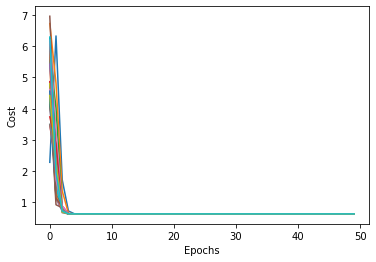

```python
#graph the loss function versus the number of epochs
plt.plot(range(len(nn.cost_)), nn.cost_)
plt.ylabel('Cost')
plt.xlabel('Epochs')
plt.show()
```

#### Normalization Results

```python
#scale the continuous variables
scaler = StandardScaler()
X_train = scaler.fit_transform(X_train)
X_test = scaler.transform(X_test)
```

```python
%%time
#call the TLPVectorizedMiniBatchCEVectorized class
nn = TLPVectorizedMiniBatchCEVectorized(n_hidden=100,
                                        C=0.1,
                                        epochs=50,
                                        eta=0.001,
                                        alpha=0.001,
                                        decrease_const=0.1,
                                        minibatches=50,
                                        shuffle=True,
                                        random_state=1)

nn.fit(X_train, y_train, print_progress=10)

yhat = nn.predict(X_test)
print('Accuracy:',accuracy_score(y_test,yhat))
```

```
Epoch: 50/50
```

```
Accuracy: 0.6476210121012101
CPU times: user 24.9 s, sys: 21 s, total: 45.9 s
Wall time: 16 s
```

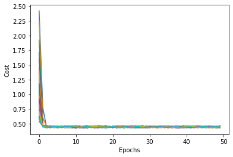

```python
#graph the loss function versus the number of epochs
plt.plot(range(len(nn.cost_)), nn.cost_)
plt.ylabel('Cost')
plt.xlabel('Epochs')
plt.show()
```

#### One-Hot Encoding and Results

```python
#import the one hot encoder
from sklearn.preprocessing import OneHotEncoder

cat_col = [8]

#one hot encode the categorical variables
encoder = OneHotEncoder(categories='auto', sparse=False, handle_unknown='ignore')

# fit the encoder on the training data
encoder.fit(X_train[:,cat_col])

# transform the categorical variable in both the training and test data
X_train_enc = encoder.transform(X_train[:,cat_col])
X_test_enc = encoder.transform(X_test[:,cat_col])

# concatenate the encoded categorical variable with the continuous variables
X_train_norm = np.concatenate((X_train[:,:8], X_train_enc), axis=1)
X_test_norm = np.concatenate((X_test[:,:8], X_test_enc), axis=1)

#concatenate the encoded categorical variable with the continuous variables after column 8
X_train_norm = np.concatenate((X_train[:,:8], X_train_enc, X_train[:,9:]), axis=1)
X_test_norm = np.concatenate((X_test[:,:8], X_test_enc, X_test[:,9:]), axis=1)
```

```python
%%time
#call the TLPVectorizedMiniBatchCEVectorized class
nn = TLPVectorizedMiniBatchCEVectorized(n_hidden=100,
                                        C=0.1,
                                        epochs=50,
                                        eta=0.001,
                                        alpha=0.001,
                                        decrease_const=0.1,
                                        minibatches=50,
                                        shuffle=True,
                                        random_state=1)

nn.fit(X_train_norm, y_train, print_progress=10)

yhat = nn.predict(X_test_norm)
print('Accuracy:',accuracy_score(y_test,yhat))
```

```
Epoch: 50/50
```

```
Accuracy: 0.666941694169417
CPU times: user 3min 25s, sys: 2min 16s, total: 5min 42s
Wall time: 1min 18s
```

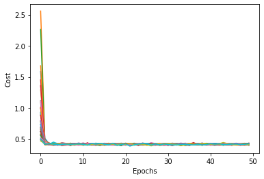

```python
#graph the loss function versus the number of epochs
plt.plot(range(len(nn.cost_)), nn.cost_)
plt.ylabel('Cost')
plt.xlabel('Epochs')
plt.show()
```

After running each version of the two-layer perceptron, we see a steady increase after each enhancement to the dataset, with the accuracy starting at 24% and jumping up to around 65% after normalization. Then, after one-hot encoding, the accuracy increased by about another 2%, bringing the accuracy to around 67%. Another notable difference in the data is that prior to one-hot encoding, the models only took around 15 seconds to run, while afterwards the timing jumps to around a minute. With the improvement in accuracy only being around 2% after one-hot encoding, it is an interesting point of consideration to think about whether or not to include one-hot encoding in this instance. If accuracy is most important, definitely encode, however if time is more important, it may be better to not encode.

# Modeling

## Three Layer Multi-Layer Perceptron

```python
class ThreeLayerPerceptron(object):
    def __init__(self, n_hidden1=30, n_hidden2=30,
                 C=0.0, epochs=500, eta=0.001, random_state=None,
                 alpha=0.1, decrease_const=0.0, shuffle=True, minibatches=1):
        np.random.seed(random_state)
        self.n_hidden1 = n_hidden1
        self.n_hidden2 = n_hidden2
        self.l2_C = C
        self.epochs = epochs
        self.eta = eta
        self.alpha = alpha
        self.decrease_const = decrease_const
        self.shuffle = shuffle
        self.minibatches = minibatches

        # create an array to store the gradient magnitude values
        self.gradW1_all_avgs = np.zeros(self.epochs)
        self.gradW2_all_avgs = np.zeros(self.epochs)
        self.gradW3_all_avgs = np.zeros(self.epochs)

    @staticmethod
    def _encode_labels(y):
        onehot = pd.get_dummies(y).values.T
        return onehot

    def _initialize_weights(self):
        glorot_factor1 = np.sqrt(6 / (self.n_features_ + self.n_hidden1))
        W1 = np.random.uniform(low=-glorot_factor1, high=glorot_factor1, size=(self.n_hidden1, self.n_features_))
        b1 = np.zeros((self.n_hidden1, 1))

        glorot_factor2 = np.sqrt(6 / (self.n_hidden1 + self.n_hidden2))
        W2 = np.random.uniform(low=-glorot_factor2, high=glorot_factor2, size=(self.n_hidden2, self.n_hidden1))
        b2 = np.zeros((self.n_hidden2, 1))

        glorot_factor3 = np.sqrt(6 / (self.n_hidden2 + self.n_output_))
        W3 = np.random.uniform(low=-glorot_factor3, high=glorot_factor3, size=(self.n_output_, self.n_hidden2))
        b3 = np.zeros((self.n_output_, 1))

        return W1, W2, W3, b1, b2, b3

    @staticmethod
    def _sigmoid(z):
        return expit(z)

    @staticmethod
    def _L2_reg(lambda_, W1, W2, W3):
        return (lambda_) * np.sqrt(np.mean(W1 ** 2) + np.mean(W2 ** 2) + np.mean(W3 ** 2))

    def _cost(self, A4, y_enc, W1, W2, W3):
        cost = np.mean(-y_enc * np.log(A4) - (1 - y_enc) * np.log(1 - A4))
        L2_term = self._L2_reg(self.l2_C, W1, W2, W3)
        return cost + L2_term

    def _feedforward(self, X, W1, W2, W3, b1, b2, b3):
        A1 = X.T
        Z1 = W1 @ A1 + b1
        A2 = self._sigmoid(Z1)
        Z2 = W2 @ A2 + b2
        A3 = self._sigmoid(Z2)
        Z3 = W3 @ A3 + b3
        A4 = self._sigmoid(Z3)
        return A1, Z1, A2, Z2, A3, Z3, A4

    def _get_gradient(self, A1, A2, A3, A4, Z1, Z2, Z3, Y_enc, W1, W2, W3):
        # vectorized backpropagation
        V3 = (A4-Y_enc) # <- this is the only line that changed
        V2 = A3*(1-A3)*(W3.T @ V3)
        V1 = A2*(1-A2)*(W2.T @ V2)

        gradW3 = V3 @ A3.T
        gradW2 = V2 @ A2.T
        gradW1 = V1 @ A1.T

        gradb3 = np.sum(V3, axis=1).reshape((-1,1))
        gradb2 = np.sum(V2, axis=1).reshape((-1,1))
        gradb1 = np.sum(V1, axis=1).reshape((-1,1))

        # regularize weights that are not bias terms
        gradW1 += W1 * self.l2_C
        gradW2 += W2 * self.l2_C
        gradW3 += W3 * self.l2_C

        return gradW1, gradW2, gradW3, gradb1, gradb2, gradb3


    def predict(self, X):
        _, _, _, _, _, _, A4 = self._feedforward(X, self.W1, self.W2, self.W3, self.b1, self.b2, self.b3)
        y_pred = np.argmax(A4, axis=0)
        return y_pred

    def fit(self, X, y, print_progress=0):
        """ Learn weights from training data."""
        X_data, y_data = X.copy(), y.copy()
        Y_enc = self._encode_labels(y)

        # init weights and setup matrices
        self.n_features_ = X_data.shape[1]
        self.n_output_ = Y_enc.shape[0]
        self.W1, self.W2, self.W3, self.b1, self.b2, self.b3 = self._initialize_weights()

        # start momentum at zero for previous updates
        rho_W1_prev = np.zeros(self.W1.shape) # for momentum
        rho_W2_prev = np.zeros(self.W2.shape) # for momentum
        rho_W3_prev = np.zeros(self.W3.shape) # for momentum

        self.cost_ = []
        for k in range(self.epochs):

            # adaptive learning rate
            eta = self.eta**(1+self.decrease_const*k)# decreasing learning rate
            eta = max(eta,self.eta/1000)
            # there are many forms of adaptive learning rates out there!

            if print_progress>0 and (k+1)%print_progress==0:
                sys.stderr.write('\rEpoch: %d/%d' % (k+1, self.epochs))
                sys.stderr.flush()

            if self.shuffle:
                # shuffle the data so batches ar different
                ridx = np.random.permutation(y_data.shape[0])
                X_data, Y_enc = X_data[ridx], Y_enc[:, ridx]

            gradW1_avg = 0
            gradW2_avg = 0
            gradW3_avg = 0

            mini = np.array_split(range(y_data.shape[0]), self.minibatches)
            mini_cost = []
            for idx in mini:

                A1, Z1, A2, Z2, A3, Z3, A4 = self._feedforward(X_data[idx], self.W1, self.W2, self.W3, self.b1, self.b2, self.b3)

                cost = self._cost(A4, Y_enc[:, idx], self.W1, self.W2, self.W3)
                mini_cost.append(cost)

                # compute gradient via backpropagation
                gradW1, gradW2, gradW3, gradb1, gradb2, gradb3 = self._get_gradient(A1, A2, A3, A4, Z1, Z2, Z3, Y_enc[:, idx], self.W1, self.W2, self.W3)

                gradW1_t = np.mean(np.abs(gradW1))
                gradW1_avg = gradW1_avg + gradW1_t

                gradW2_t = np.mean(np.abs(gradW2))
                gradW2_avg = gradW2_avg + gradW2_t

                gradW3_t = np.mean(np.abs(gradW3))
                gradW3_avg = gradW3_avg + gradW3_t

                # momentum
                rho_W1 = self.eta * gradW1 + self.alpha * rho_W1_prev
                rho_W2 = self.eta * gradW2 + self.alpha * rho_W2_prev
                rho_W3 = self.eta * gradW3 + self.alpha * rho_W3_prev
                self.W1 -= rho_W1
                self.W2 -= rho_W2
                self.W3 -= rho_W3
                self.b1 -= self.eta * gradb1
                self.b2 -= self.eta * gradb2
                self.b3 -= self.eta * gradb3

                rho_W1_prev = rho_W1
                rho_W2_prev = rho_W2
                rho_W3_prev = rho_W3

            #keep track of the gradient weight
            self.gradW1_all_avgs[k] = gradW1_avg/len(mini)
            self.gradW2_all_avgs[k] = gradW2_avg/len(mini)
            self.gradW3_all_avgs[k] = gradW3_avg/len(mini)

            self.cost_.append(np.mean(mini_cost))

        return self
```

```python
%%time
#run the ThreeLayerPerceptron class
threelpnn = ThreeLayerPerceptron(n_hidden1 = 50, n_hidden2 = 50, C = 0.1, epochs = 50, eta = 0.01, alpha = 0.1, decrease_const = 0.1, minibatches = 100, shuffle = True, random_state = 1)
threelpnn.fit(X_train_norm, y_train, print_progress=10)

yhat = threelpnn.predict(X_test_norm)
print('Accuracy:',accuracy_score(y_test,yhat))
```

```
Epoch: 50/50
```

```
Accuracy: 0.7004950495049505
CPU times: user 2min 56s, sys: 2min 29s, total: 5min 25s
Wall time: 1min 21s
```

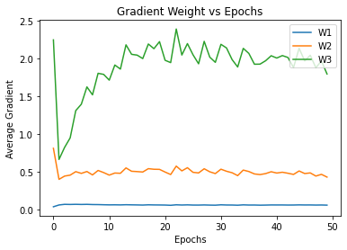

```
Accuracy: 0.7004950495049505
```

```python
# plot a line graph of the average gradient of the weights
ax = plt.subplot(1,1,1)
plt.plot(abs(threelpnn.gradW1_all_avgs), label='W1')
plt.plot(abs(threelpnn.gradW2_all_avgs), label='W2')
plt.plot(abs(threelpnn.gradW3_all_avgs), label='W3')
plt.xlabel('Epochs')
plt.ylabel('Average Gradient')
plt.legend(loc='upper right')
plt.title('Gradient Weight vs Epochs')
plt.show()
print('Accuracy:',accuracy_score(y_test,yhat))
```

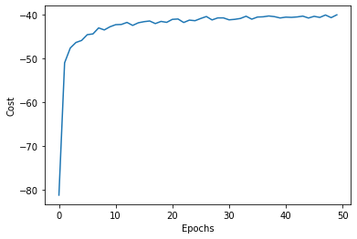

```python
#graph the cost
plt.plot(range(len(threelpnn.cost_)), threelpnn.cost_)
plt.ylabel('Cost')
plt.xlabel('Epochs')
plt.show()
```

## Four Layer Multi-Layer Perceptron

```python
class FourLayerPerceptron(object):
    def __init__(self, n_hidden1=30, n_hidden2=30, n_hidden3=30,
                 C=0.0, epochs=500, eta=0.001, random_state=None,
                 alpha=0.1, decrease_const=0.0, shuffle=True, minibatches=1):
        np.random.seed(random_state)
        self.n_hidden1 = n_hidden1
        self.n_hidden2 = n_hidden2
        self.n_hidden3 = n_hidden3
        self.l2_C = C
        self.epochs = epochs
        self.eta = eta
        self.alpha = alpha
        self.decrease_const = decrease_const
        self.shuffle = shuffle
        self.minibatches = minibatches

        self.gradW1_all_avgs = np.zeros(self.epochs)
        self.gradW2_all_avgs = np.zeros(self.epochs)
        self.gradW3_all_avgs = np.zeros(self.epochs)
        self.gradW4_all_avgs = np.zeros(self.epochs)

    @staticmethod
    def _encode_labels(y):
        onehot = pd.get_dummies(y).values.T
        return onehot

    def _initialize_weights(self):
        glorot_factor1 = np.sqrt(6 / (self.n_features_ + self.n_hidden1))
        W1 = np.random.uniform(low=-glorot_factor1, high=glorot_factor1, size=(self.n_hidden1, self.n_features_))
        b1 = np.zeros((self.n_hidden1, 1))

        glorot_factor2 = np.sqrt(6 / (self.n_hidden1 + self.n_hidden2))
        W2 = np.random.uniform(low=-glorot_factor2, high=glorot_factor2, size=(self.n_hidden2, self.n_hidden1))
        b2 = np.zeros((self.n_hidden2, 1))

        glorot_factor3 = np.sqrt(6 / (self.n_hidden2 + self.n_hidden3))
        W3 = np.random.uniform(low=-glorot_factor3, high=glorot_factor3, size=(self.n_hidden3, self.n_hidden2))
        b3 = np.zeros((self.n_hidden3, 1))

        glorot_factor4 = np.sqrt(6 / (self.n_hidden3 + self.n_output_))
        W4 = np.random.uniform(low=-glorot_factor4, high=glorot_factor4, size=(self.n_output_, self.n_hidden3))
        b4 = np.zeros((self.n_output_, 1))

        return W1, W2, W3, W4, b1, b2, b3, b4

    @staticmethod
    def _sigmoid(z):
        return expit(z)

    @staticmethod
    def _L2_reg(lambda_, W1, W2, W3, W4):
        return (lambda_) * np.sqrt(np.mean(W1 ** 2) + np.mean(W2 ** 2) + np.mean(W3 ** 2) + np.mean(W4 ** 2))

    def _cost(self, A5, Y_enc, W1, W2, W3, W4):
        cost = np.mean(-Y_enc * np.log(A5) - (1 - Y_enc) * np.log(1 - A5))
        L2_term = self._L2_reg(self.l2_C, W1, W2, W3, W4)
        return cost + L2_term

    def _feedforward(self, X, W1, W2, W3, W4, b1, b2, b3, b4):
        A1 = X.T
        Z1 = W1 @ A1 + b1
        A2 = self._sigmoid(Z1)
        Z2 = W2 @ A2 + b2
        A3 = self._sigmoid(Z2)
        Z3 = W3 @ A3 + b3
        A4 = self._sigmoid(Z3)
        Z4 = W4 @ A4 + b4
        A5 = self._sigmoid(Z4)
        return A1, Z1, A2, Z2, A3, Z3, A4, Z4, A5


    def _get_gradient(self, A1, A2, A3, A4, A5, Z1, Z2, Z3, Z4, Y_enc, W1, W2, W3, W4):
        V4 = (A5 - Y_enc)
        V3 = A4*(1-A4)*(W4.T @ V4)
        V2 = A3*(1-A3)*(W3.T @ V3)
        V1 = A2*(1-A2)*(W2.T @ V2)

        gradW4 = V4 @ A4.T
        gradW3 = V3 @ A3.T
        gradW2 = V2 @ A2.T
        gradW1 = V1 @ A1.T

        gradb4 = np.sum(V4, axis=1).reshape(-1, 1)
        gradb3 = np.sum(V3, axis=1).reshape(-1, 1)
        gradb2 = np.sum(V2, axis=1).reshape(-1, 1)
        gradb1 = np.sum(V1, axis=1).reshape(-1, 1)

        gradW1 += W1 * self.l2_C
        gradW2 += W2 * self.l2_C
        gradW3 += W3 * self.l2_C
        gradW4 += W4 * self.l2_C

        return gradW1, gradW2, gradW3, gradW4, gradb1, gradb2, gradb3, gradb4


    def predict(self, X):
        _, _, _, _, _, _, _, _, A5 = self._feedforward(X, self.W1, self.W2, self.W3, self.W4, self.b1, self.b2, self.b3, self.b4)
        y_pred = np.argmax(A5, axis=0)
        return y_pred

    def fit(self, X, y, print_progress=0):
        """ Learn weights from training data."""
        X_data, y_data = X.copy(), y.copy()
        Y_enc = self._encode_labels(y)

        # init weights and setup matrices
        self.n_features_ = X_data.shape[1]
        self.n_output_ = Y_enc.shape[0]
        self.W1, self.W2, self.W3, self.W4, self.b1, self.b2, self.b3, self.b4 = self._initialize_weights()

        #initialize gradient matrices
        self.delta_W1_prev = np.zeros((self.epochs))
        self.delta_W2_prev = np.zeros((self.epochs))
        self.delta_W3_prev = np.zeros((self.epochs))
        self.delta_W4_prev = np.zeros((self.epochs))

        # start momentum at zero for previous updates
        rho_W1_prev = np.zeros(self.W1.shape) # for momentum
        rho_W2_prev = np.zeros(self.W2.shape) # for momentum
        rho_W3_prev = np.zeros(self.W3.shape) # for momentum
        rho_W4_prev = np.zeros(self.W4.shape) # for momentum

        self.cost_ = []
        for k in range(self.epochs):

            #adaptive learning rate
            eta = self.eta**(1+self.decrease_const*k)# decreasing learning rate
            eta = max(eta,self.eta/1000)

            if print_progress>0 and (k+1)%print_progress==0:
                sys.stderr.write('\rEpoch: %d/%d' % (k+1, self.epochs))
                sys.stderr.flush()

            if self.shuffle:
                # shuffle the data so batches ar different
                ridx = np.random.permutation(y_data.shape[0])
                X_data, Y_enc = X_data[ridx], Y_enc[:, ridx]

            gradW1_avg = 0
            gradW2_avg = 0
            gradW3_avg = 0
            gradW4_avg = 0

            mini = np.array_split(range(y_data.shape[0]), self.minibatches)
            mini_cost = []
            for idx in mini:

                # feedforward
                A1, Z1, A2, Z2, A3, Z3, A4, Z4, A5 = self._feedforward(X_data[idx], self.W1, self.W2, self.W3, self.W4, self.b1, self.b2, self.b3, self.b4)

                # compute cost
                cost = self._cost(A5, Y_enc[:, idx], self.W1, self.W2, self.W3, self.W4)
                mini_cost.append(cost)

                # compute gradient via backpropagation
                gradW1, gradW2, gradW3, gradW4, gradb1, gradb2, gradb3, gradb4 = self._get_gradient(A1, A2, A3, A4, A5, Z1, Z2, Z3, Z4, Y_enc[:, idx], self.W1, self.W2, self.W3, self.W4)

                gradW1_t = np.mean(np.abs(gradW1))
                gradW1_avg = gradW1_avg + gradW1_t

                gradW2_t = np.mean(np.abs(gradW2))
                gradW2_avg = gradW2_avg + gradW2_t

                gradW3_t = np.mean(np.abs(gradW3))
                gradW3_avg = gradW3_avg + gradW3_t

                gradW4_t = np.mean(np.abs(gradW4))
                gradW4_avg = gradW4_avg + gradW4_t

                # momentum
                rho_W1 = self.eta * gradW1 + self.alpha * rho_W1_prev
                rho_W2 = self.eta * gradW2 + self.alpha * rho_W2_prev
                rho_W3 = self.eta * gradW3 + self.alpha * rho_W3_prev
                rho_W4 = self.eta * gradW4 + self.alpha * rho_W4_prev

                # update weights
                self.W1 -= rho_W1
                self.W2 -= rho_W2
                self.W3 -= rho_W3
                self.W4 -= rho_W4

                # update bias
                self.b1 -= self.eta * gradb1
                self.b2 -= self.eta * gradb2
                self.b3 -= self.eta * gradb3
                self.b4 -= self.eta * gradb4

                # save previous momentum
                rho_W1_prev = rho_W1
                rho_W2_prev = rho_W2
                rho_W3_prev = rho_W3
                rho_W4_prev = rho_W4

            #keep track of the gradient weight
            self.gradW1_all_avgs[k] = gradW1_avg/len(mini)
            self.gradW2_all_avgs[k] = gradW2_avg/len(mini)
            self.gradW3_all_avgs[k] = gradW3_avg/len(mini)
            self.gradW4_all_avgs[k] = gradW4_avg/len(mini)

            self.cost_.append(np.mean(mini_cost))

        return self
```

```python
%%time
#run the FourLayerPerceptron class
fourlpnn = FourLayerPerceptron(n_hidden1 = 50, n_hidden2 = 50, n_hidden3 = 50, C = 0.1, epochs = 50, eta = 0.01, alpha = 0.1, decrease_const = 0.1, minibatches = 100, shuffle = True, random_state = 1)
fourlpnn.fit(X_train_norm, y_train, print_progress=10)

yhat = fourlpnn.predict(X_test_norm)
print('Accuracy:',accuracy_score(y_test,yhat))
```

```
Epoch: 50/50
```

```
Accuracy: 0.7084708470847084
CPU times: user 3min 10s, sys: 2min 36s, total: 5min 47s
Wall time: 1min 35s
```

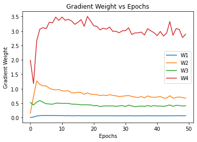

```python
#plot the magnitude of the gradient weights
ax = plt.subplot(1,1,1)
plt.plot(abs(fourlpnn.gradW1_all_avgs), label = 'W1')
plt.plot(abs(fourlpnn.gradW2_all_avgs), label = 'W2')
plt.plot(abs(fourlpnn.gradW3_all_avgs), label = 'W3')
plt.plot(abs(fourlpnn.gradW4_all_avgs), label = 'W4')
plt.legend()
plt.xlabel('Epochs')
plt.ylabel('Gradient Weight')
plt.title('Gradient Weight vs Epochs')
plt.show()
```

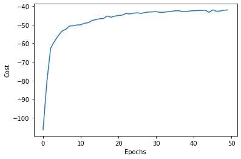

```python
#plot the cost
plt.plot(range(len(fourlpnn.cost_)), fourlpnn.cost_)
plt.ylabel('Cost')
plt.xlabel('Epochs')
plt.show()
```

## Five Layer Multi-Layer Perceptron

```python
class FiveLayerPerceptron(object):
    def __init__(self, n_hidden1=30, n_hidden2=30, n_hidden3=30, n_hidden4 = 30,
                 C=0.0, epochs=500, eta=0.001, random_state=None,
                 alpha=0.1, decrease_const=0.0, shuffle=True, minibatches=1):
        np.random.seed(random_state)
        self.n_hidden1 = n_hidden1
        self.n_hidden2 = n_hidden2
        self.n_hidden3 = n_hidden3
        self.n_hidden4 = n_hidden4
        self.l2_C = C
        self.epochs = epochs
        self.eta = eta
        self.alpha = alpha
        self.decrease_const = decrease_const
        self.shuffle = shuffle
        self.minibatches = minibatches

        self.gradW1_all_avgs = np.zeros(self.epochs)
        self.gradW2_all_avgs = np.zeros(self.epochs)
        self.gradW3_all_avgs = np.zeros(self.epochs)
        self.gradW4_all_avgs = np.zeros(self.epochs)
        self.gradW5_all_avgs = np.zeros(self.epochs)

    @staticmethod
    def _encode_labels(y):
        onehot = pd.get_dummies(y).values.T
        return onehot

    def _initialize_weights(self):
        glorot_factor1 = np.sqrt(6 / (self.n_features_ + self.n_hidden1))
        W1 = np.random.uniform(low=-glorot_factor1, high=glorot_factor1, size=(self.n_hidden1, self.n_features_))
        b1 = np.zeros((self.n_hidden1, 1))

        glorot_factor2 = np.sqrt(6 / (self.n_hidden1 + self.n_hidden2))
        W2 = np.random.uniform(low=-glorot_factor2, high=glorot_factor2, size=(self.n_hidden2, self.n_hidden1))
        b2 = np.zeros((self.n_hidden2, 1))

        glorot_factor3 = np.sqrt(6 / (self.n_hidden2 + self.n_hidden3))
        W3 = np.random.uniform(low=-glorot_factor3, high=glorot_factor3, size=(self.n_hidden3, self.n_hidden2))
        b3 = np.zeros((self.n_hidden3, 1))

        glorot_factor4 = np.sqrt(6 / (self.n_hidden3 + self.n_hidden4))
        W4 = np.random.uniform(low=-glorot_factor4, high=glorot_factor4, size=(self.n_hidden4, self.n_hidden3))
        b4 = np.zeros((self.n_hidden4, 1))

        glorot_factor5 = np.sqrt(6 / (self.n_hidden4 + self.n_output_))
        W5 = np.random.uniform(low=-glorot_factor5, high=glorot_factor5, size=(self.n_output_, self.n_hidden4))
        b5 = np.zeros((self.n_output_, 1))

        return W1, W2, W3, W4, W5, b1, b2, b3, b4, b5

    @staticmethod
    def _sigmoid(z):
        return expit(z)

    @staticmethod
    def _L2_reg(lambda_, W1, W2, W3, W4, W5):
        return (lambda_) * np.sqrt(np.mean(W1 ** 2) + np.mean(W2 ** 2) + np.mean(W3 ** 2) + np.mean(W4 ** 2) + np.mean(W5 ** 2))

    def _cost(self, A6, Y_enc, W1, W2, W3, W4, W5):
        cost = np.mean(-Y_enc * np.log(A6) - (1 - Y_enc) * np.log(1 - A6))
        L2_term = self._L2_reg(self.l2_C, W1, W2, W3, W4, W5)
        return cost + L2_term

    def _feedforward(self, X, W1, W2, W3, W4, W5, b1, b2, b3, b4, b5):
        A1 = X.T
        Z1 = W1 @ A1 + b1
        A2 = self._sigmoid(Z1)
        Z2 = W2 @ A2 + b2
        A3 = self._sigmoid(Z2)
        Z3 = W3 @ A3 + b3
        A4 = self._sigmoid(Z3)
        Z4 = W4 @ A4 + b4
        A5 = self._sigmoid(Z4)
        Z5 = W5 @ A5 + b5
        A6 = self._sigmoid(Z5)
        return A1, Z1, A2, Z2, A3, Z3, A4, Z4, A5, Z5, A6


    def _get_gradient(self, A1, A2, A3, A4, A5, A6, Z1, Z2, Z3, Z4, Z5, Y_enc, W1, W2, W3, W4, W5):
        V5 = (A6 - Y_enc)
        V4 = A5*(1-A5)*(W5.T @ V5)
        V3 = A4*(1-A4)*(W4.T @ V4)
        V2 = A3*(1-A3)*(W3.T @ V3)
        V1 = A2*(1-A2)*(W2.T @ V2)

        gradW5 = V5 @ A5.T
        gradW4 = V4 @ A4.T
        gradW3 = V3 @ A3.T
        gradW2 = V2 @ A2.T
        gradW1 = V1 @ A1.T

        gradb5 = np.sum(V5, axis=1).reshape(-1, 1)
        gradb4 = np.sum(V4, axis=1).reshape(-1, 1)
        gradb3 = np.sum(V3, axis=1).reshape(-1, 1)
        gradb2 = np.sum(V2, axis=1).reshape(-1, 1)
        gradb1 = np.sum(V1, axis=1).reshape(-1, 1)

        gradW1 += (self.l2_C * W1)
        gradW2 += (self.l2_C * W2)
        gradW3 += (self.l2_C * W3)
        gradW4 += (self.l2_C * W4)
        gradW5 += (self.l2_C * W5)

        return gradW1, gradW2, gradW3, gradW4, gradW5, gradb1, gradb2, gradb3, gradb4, gradb5


    def predict(self, X):
        _, _, _, _, _, _, _, _, _, _, A6 = self._feedforward(X, self.W1, self.W2, self.W3, self.W4, self.W5, self.b1, self.b2, self.b3, self.b4, self.b5)
        y_pred = np.argmax(A6, axis=0)
        return y_pred

    def fit(self, X, y, print_progress=0):
        """ Learn weights from training data."""
        X_data, y_data = X.copy(), y.copy()
        Y_enc = self._encode_labels(y)

        # init weights and setup matrices
        self.n_features_ = X_data.shape[1]
        self.n_output_ = Y_enc.shape[0]
        self.W1, self.W2, self.W3, self.W4, self.W5, self.b1, self.b2, self.b3, self.b4, self.b5 = self._initialize_weights()

        #initialize gradient matrices
        self.delta_W1_prev = np.zeros((self.epochs))
        self.delta_W2_prev = np.zeros((self.epochs))
        self.delta_W3_prev = np.zeros((self.epochs))
        self.delta_W4_prev = np.zeros((self.epochs))
        self.delta_W5_prev = np.zeros((self.epochs))

        # start momentum at zero for previous updates
        rho_W1_prev = np.zeros(self.W1.shape) # for momentum
        rho_W2_prev = np.zeros(self.W2.shape) # for momentum
        rho_W3_prev = np.zeros(self.W3.shape) # for momentum
        rho_W4_prev = np.zeros(self.W4.shape) # for momentum
        rho_W5_prev = np.zeros(self.W5.shape) # for momentum

        self.cost_ = []
        for k in range(self.epochs):

            #adaptive learning rate
            eta = self.eta**(1+self.decrease_const*k)# decreasing learning rate
            eta = max(eta,self.eta/1000)

            if print_progress>0 and (k+1)%print_progress==0:
                sys.stderr.write('\rEpoch: %d/%d' % (k+1, self.epochs))
                sys.stderr.flush()

            if self.shuffle:
                # shuffle the data so batches ar different
                ridx = np.random.permutation(y_data.shape[0])
                X_data, Y_enc = X_data[ridx], Y_enc[:, ridx]

            gradW1_avg = 0
            gradW2_avg = 0
            gradW3_avg = 0
            gradW4_avg = 0
            gradW5_avg = 0

            mini = np.array_split(range(y_data.shape[0]), self.minibatches)
            mini_cost = []
            for idx in mini:

                # feedforward
                A1, Z1, A2, Z2, A3, Z3, A4, Z4, A5, Z5, A6 = self._feedforward(X_data[idx], self.W1, self.W2, self.W3, self.W4, self.W5, self.b1, self.b2, self.b3, self.b4, self.b5)

                # compute cost
                cost = self._cost(A6, Y_enc[:, idx], self.W1, self.W2, self.W3, self.W4, self.W5)
                mini_cost.append(cost)

                # compute gradient via backpropagation
                gradW1, gradW2, gradW3, gradW4, gradW5, gradb1, gradb2, gradb3, gradb4, gradb5 = self._get_gradient(A1, A2, A3, A4, A5, A6, Z1, Z2, Z3, Z4, Z5, Y_enc[:, idx], self.W1, self.W2, self.W3, self.W4, self.W5)

                gradW1_t = np.mean(np.abs(gradW1))
                gradW1_avg = gradW1_avg + gradW1_t

                gradW2_t = np.mean(np.abs(gradW2))
                gradW2_avg = gradW2_avg + gradW2_t

                gradW3_t = np.mean(np.abs(gradW3))
                gradW3_avg = gradW3_avg + gradW3_t

                gradW4_t = np.mean(np.abs(gradW4))
                gradW4_avg = gradW4_avg + gradW4_t

                gradW5_t = np.mean(np.abs(gradW5))
                gradW5_avg = gradW5_avg + gradW5_t

                # momentum
                rho_W1 = self.eta * gradW1 + self.alpha * rho_W1_prev
                rho_W2 = self.eta * gradW2 + self.alpha * rho_W2_prev
                rho_W3 = self.eta * gradW3 + self.alpha * rho_W3_prev
                rho_W4 = self.eta * gradW4 + self.alpha * rho_W4_prev
                rho_W5 = self.eta * gradW5 + self.alpha * rho_W5_prev

                # update weights
                self.W1 -= rho_W1
                self.W2 -= rho_W2
                self.W3 -= rho_W3
                self.W4 -= rho_W4
                self.W5 -= rho_W5

                # update bias
                self.b1 -= self.eta * gradb1
                self.b2 -= self.eta * gradb2
                self.b3 -= self.eta * gradb3
                self.b4 -= self.eta * gradb4
                self.b5 -= self.eta * gradb5

                # save previous momentum
                rho_W1_prev = rho_W1
                rho_W2_prev = rho_W2
                rho_W3_prev = rho_W3
                rho_W4_prev = rho_W4
                rho_W5_prev = rho_W5

            #keep track of the gradient weight
            self.gradW1_all_avgs[k] = gradW1_avg/len(mini)
            self.gradW2_all_avgs[k] = gradW2_avg/len(mini)
            self.gradW3_all_avgs[k] = gradW3_avg/len(mini)
            self.gradW4_all_avgs[k] = gradW4_avg/len(mini)
            self.gradW5_all_avgs[k] = gradW5_avg/len(mini)

            self.cost_.append(np.mean(mini_cost))

        return self
```

```python
%%time
#run the FiveLayerPerceptron class
fivelpnn = FiveLayerPerceptron(n_hidden1 = 50, n_hidden2 = 50, n_hidden3 = 50, n_hidden4 = 50, C = 0.1, epochs = 50, eta = 0.01, alpha = 0.1, decrease_const = 0.1, minibatches = 100, shuffle = True, random_state = 1)
fivelpnn.fit(X_train_norm, y_train, print_progress=10)

yhat = fivelpnn.predict(X_test_norm)
print('Accuracy:',accuracy_score(y_test,yhat))
```

```
Epoch: 50/50
```

```
Accuracy: 0.7003575357535754
CPU times: user 3min 35s, sys: 2min 59s, total: 6min 35s
Wall time: 1min 39s
```

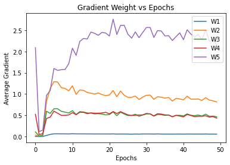

```python
# plot a line graph of the average gradient of the weights
ax = plt.subplot(1,1,1)
plt.plot(abs(fivelpnn.gradW1_all_avgs), label='W1')
plt.plot(abs(fivelpnn.gradW2_all_avgs), label='W2')
plt.plot(abs(fivelpnn.gradW3_all_avgs), label='W3')
plt.plot(abs(fivelpnn.gradW4_all_avgs), label='W4')
plt.plot(abs(fivelpnn.gradW5_all_avgs), label='W5')
plt.ylabel('Average Gradient')
plt.xlabel('Epochs')
plt.legend(loc='upper right')
plt.title('Gradient Weight vs Epochs')
plt.show()
```

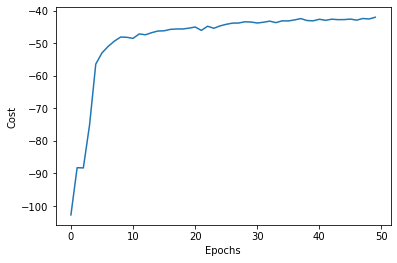

```python
#plot the cost
plt.plot(range(len(fivelpnn.cost_)), fivelpnn.cost_)
plt.ylabel('Cost')
plt.xlabel('Epochs')
plt.show()
```

The five layer perceptron yields a worse accuracy rate than the previous multi-layer classifiers before it, which were showing a trend of increasing accuracy rates. This is most likely due to the fact that the five layer perceptron is overfitting the data. This can lead to worse generalization which is apparent in the lower accuracy percentage.

## Adaptive Learning Technique Implementation

For an adaptive learning technique, we chose AdaGrad because it adapts its learning rates based off of the historical gradient data. We believed that this would be a good fit for our data, helping to narrow down a better gradient based off of the previous gradient data that we were generating.

```python
class AdaFiveLayerPerceptron(object):
    def __init__(self, n_hidden1=30, n_hidden2=30, n_hidden3=30, n_hidden4 = 30,
                 C=0.0, epochs=500, eta=0.001, random_state=None,
                 alpha=0.1, decrease_const=0.0, shuffle=True, minibatches=1):
        np.random.seed(random_state)
        self.n_hidden1 = n_hidden1
        self.n_hidden2 = n_hidden2
        self.n_hidden3 = n_hidden3
        self.n_hidden4 = n_hidden4
        self.l2_C = C
        self.epochs = epochs
        self.eta = eta
        self.alpha = alpha
        self.decrease_const = decrease_const
        self.shuffle = shuffle
        self.minibatches = minibatches
        self.eps = 1e-8

        self.gradW1_all_avgs = np.zeros(self.epochs)
        self.gradW2_all_avgs = np.zeros(self.epochs)
        self.gradW3_all_avgs = np.zeros(self.epochs)
        self.gradW4_all_avgs = np.zeros(self.epochs)
        self.gradW5_all_avgs = np.zeros(self.epochs)

    @staticmethod
    def _encode_labels(y):
        onehot = pd.get_dummies(y).values.T
        return onehot

    def _initialize_weights(self):
        glorot_factor1 = np.sqrt(6 / (self.n_features_ + self.n_hidden1))
        W1 = np.random.uniform(low=-glorot_factor1, high=glorot_factor1, size=(self.n_hidden1, self.n_features_))
        b1 = np.zeros((self.n_hidden1, 1))

        glorot_factor2 = np.sqrt(6 / (self.n_hidden1 + self.n_hidden2))
        W2 = np.random.uniform(low=-glorot_factor2, high=glorot_factor2, size=(self.n_hidden2, self.n_hidden1))
        b2 = np.zeros((self.n_hidden2, 1))

        glorot_factor3 = np.sqrt(6 / (self.n_hidden2 + self.n_hidden3))
        W3 = np.random.uniform(low=-glorot_factor3, high=glorot_factor3, size=(self.n_hidden3, self.n_hidden2))
        b3 = np.zeros((self.n_hidden3, 1))

        glorot_factor4 = np.sqrt(6 / (self.n_hidden3 + self.n_hidden4))
        W4 = np.random.uniform(low=-glorot_factor4, high=glorot_factor4, size=(self.n_hidden4, self.n_hidden3))
        b4 = np.zeros((self.n_hidden4, 1))

        glorot_factor5 = np.sqrt(6 / (self.n_hidden4 + self.n_output_))
        W5 = np.random.uniform(low=-glorot_factor5, high=glorot_factor5, size=(self.n_output_, self.n_hidden4))
        b5 = np.zeros((self.n_output_, 1))

        return W1, W2, W3, W4, W5, b1, b2, b3, b4, b5

    @staticmethod
    def _sigmoid(z):
        return expit(z)

    @staticmethod
    def _L2_reg(lambda_, W1, W2, W3, W4, W5):
        return (lambda_) * np.sqrt(np.mean(W1 ** 2) + np.mean(W2 ** 2) + np.mean(W3 ** 2) + np.mean(W4 ** 2) + np.mean(W5 ** 2))

    def _cost(self, A6, Y_enc, W1, W2, W3, W4, W5):
        cost = np.mean(-Y_enc * np.log(A6) - (1 - Y_enc) * np.log(1 - A6))
        L2_term = self._L2_reg(self.l2_C, W1, W2, W3, W4, W5)
        return cost + L2_term

    def _feedforward(self, X, W1, W2, W3, W4, W5, b1, b2, b3, b4, b5):
        A1 = X.T
        Z1 = W1 @ A1 + b1
        A2 = self._sigmoid(Z1)
        Z2 = W2 @ A2 + b2
        A3 = self._sigmoid(Z2)
        Z3 = W3 @ A3 + b3
        A4 = self._sigmoid(Z3)
        Z4 = W4 @ A4 + b4
        A5 = self._sigmoid(Z4)
        Z5 = W5 @ A5 + b5
        A6 = self._sigmoid(Z5)
        return A1, Z1, A2, Z2, A3, Z3, A4, Z4, A5, Z5, A6


    def _get_gradient(self, A1, A2, A3, A4, A5, A6, Z1, Z2, Z3, Z4, Z5, Y_enc, W1, W2, W3, W4, W5):
        V5 = (A6 - Y_enc)
        V4 = A5*(1-A5)*(W5.T @ V5)
        V3 = A4*(1-A4)*(W4.T @ V4)
        V2 = A3*(1-A3)*(W3.T @ V3)
        V1 = A2*(1-A2)*(W2.T @ V2)

        gradW5 = V5 @ A5.T
        gradW4 = V4 @ A4.T
        gradW3 = V3 @ A3.T
        gradW2 = V2 @ A2.T
        gradW1 = V1 @ A1.T

        gradb5 = np.sum(V5, axis=1).reshape(-1, 1)
        gradb4 = np.sum(V4, axis=1).reshape(-1, 1)
        gradb3 = np.sum(V3, axis=1).reshape(-1, 1)
        gradb2 = np.sum(V2, axis=1).reshape(-1, 1)
        gradb1 = np.sum(V1, axis=1).reshape(-1, 1)

        gradW1 += (self.l2_C * W1)
        gradW2 += (self.l2_C * W2)
        gradW3 += (self.l2_C * W3)
        gradW4 += (self.l2_C * W4)
        gradW5 += (self.l2_C * W5)

        return gradW1, gradW2, gradW3, gradW4, gradW5, gradb1, gradb2, gradb3, gradb4, gradb5


    def predict(self, X):
        _, _, _, _, _, _, _, _, _, _, A6 = self._feedforward(X, self.W1, self.W2, self.W3, self.W4, self.W5, self.b1, self.b2, self.b3, self.b4, self.b5)
        y_pred = np.argmax(A6, axis=0)
        return y_pred

    def fit(self, X, y, print_progress=0):
        """ Learn weights from training data."""
        X_data, y_data = X.copy(), y.copy()
        Y_enc = self._encode_labels(y)

        # init weights and setup matrices
        self.n_features_ = X_data.shape[1]
        self.n_output_ = Y_enc.shape[0]
        self.W1, self.W2, self.W3, self.W4, self.W5, self.b1, self.b2, self.b3, self.b4, self.b5 = self._initialize_weights()

        accumulated_gradW1_sq = np.zeros(self.W1.shape)
        accumulated_gradW2_sq = np.zeros(self.W2.shape)
        accumulated_gradW3_sq = np.zeros(self.W3.shape)
        accumulated_gradW4_sq = np.zeros(self.W4.shape)
        accumulated_gradW5_sq = np.zeros(self.W5.shape)
        accumulated_gradb1_sq = np.zeros(self.b1.shape)
        accumulated_gradb2_sq = np.zeros(self.b2.shape)
        accumulated_gradb3_sq = np.zeros(self.b3.shape)
        accumulated_gradb4_sq = np.zeros(self.b4.shape)
        accumulated_gradb5_sq = np.zeros(self.b5.shape)

        #initialize gradient matrices
        self.delta_W1_prev = np.zeros((self.epochs))
        self.delta_W2_prev = np.zeros((self.epochs))
        self.delta_W3_prev = np.zeros((self.epochs))
        self.delta_W4_prev = np.zeros((self.epochs))
        self.delta_W5_prev = np.zeros((self.epochs))

        # start momentum at zero for previous updates
        rho_W1_prev = np.zeros(self.W1.shape) # for momentum
        rho_W2_prev = np.zeros(self.W2.shape) # for momentum
        rho_W3_prev = np.zeros(self.W3.shape) # for momentum
        rho_W4_prev = np.zeros(self.W4.shape) # for momentum
        rho_W5_prev = np.zeros(self.W5.shape) # for momentum

        self.cost_ = []
        for k in range(self.epochs):

            #adaptive learning rate
            eta = self.eta**(1+self.decrease_const*k)# decreasing learning rate
            eta = max(eta,self.eta/1000)

            if print_progress>0 and (k+1)%print_progress==0:
                sys.stderr.write('\rEpoch: %d/%d' % (k+1, self.epochs))
                sys.stderr.flush()

            if self.shuffle:
                # shuffle the data so batches ar different
                ridx = np.random.permutation(y_data.shape[0])
                X_data, Y_enc = X_data[ridx], Y_enc[:, ridx]

            gradW1_avg = 0
            gradW2_avg = 0
            gradW3_avg = 0
            gradW4_avg = 0
            gradW5_avg = 0

            mini = np.array_split(range(y_data.shape[0]), self.minibatches)
            mini_cost = []
            for idx in mini:

                # feedforward
                A1, Z1, A2, Z2, A3, Z3, A4, Z4, A5, Z5, A6 = self._feedforward(X_data[idx], self.W1, self.W2, self.W3, self.W4, self.W5, self.b1, self.b2, self.b3, self.b4, self.b5)

                # compute cost
                cost = self._cost(A6, Y_enc[:, idx], self.W1, self.W2, self.W3, self.W4, self.W5)
                mini_cost.append(cost)

                # compute gradient via backpropagation
                gradW1, gradW2, gradW3, gradW4, gradW5, gradb1, gradb2, gradb3, gradb4, gradb5 = self._get_gradient(A1, A2, A3, A4, A5, A6, Z1, Z2, Z3, Z4, Z5, Y_enc[:, idx], self.W1, self.W2, self.W3, self.W4, self.W5)

                gradW1_t = np.mean(np.abs(gradW1))
                gradW1_avg = gradW1_avg + gradW1_t

                gradW2_t = np.mean(np.abs(gradW2))
                gradW2_avg = gradW2_avg + gradW2_t

                gradW3_t = np.mean(np.abs(gradW3))
                gradW3_avg = gradW3_avg + gradW3_t

                gradW4_t = np.mean(np.abs(gradW4))
                gradW4_avg = gradW4_avg + gradW4_t

                gradW5_t = np.mean(np.abs(gradW5))
                gradW5_avg = gradW5_avg + gradW5_t

                # squared accumulated gradients
                accumulated_gradW1_sq += gradW1**2
                accumulated_gradW2_sq += gradW2**2
                accumulated_gradW3_sq += gradW3**2
                accumulated_gradW4_sq += gradW4**2
                accumulated_gradW5_sq += gradW5**2
                accumulated_gradb1_sq += gradb1**2
                accumulated_gradb2_sq += gradb2**2
                accumulated_gradb3_sq += gradb3**2
                accumulated_gradb4_sq += gradb4**2
                accumulated_gradb5_sq += gradb5**2

                # momentum
                rho_W1 = self.eta * gradW1 + self.alpha * rho_W1_prev
                rho_W2 = self.eta * gradW2 + self.alpha * rho_W2_prev
                rho_W3 = self.eta * gradW3 + self.alpha * rho_W3_prev
                rho_W4 = self.eta * gradW4 + self.alpha * rho_W4_prev
                rho_W5 = self.eta * gradW5 + self.alpha * rho_W5_prev

                # update weights
                self.W1 -= rho_W1
                self.W2 -= rho_W2
                self.W3 -= rho_W3
                self.W4 -= rho_W4
                self.W5 -= rho_W5

                # adagrad updates
                # self.W1 = self.W1 - eta * gradW1 / (np.sqrt(np.sum(gradW1**2)) + self.eps)
                self.W1 = self.W1 - eta * gradW1 / (np.sqrt(accumulated_gradW1_sq) + self.eps)
                self.W2 = self.W2 - eta * gradW2 / (np.sqrt(accumulated_gradW2_sq) + self.eps)
                self.W3 = self.W3 - eta * gradW3 / (np.sqrt(accumulated_gradW3_sq) + self.eps)
                self.W4 = self.W4 - eta * gradW4 / (np.sqrt(accumulated_gradW4_sq) + self.eps)
                self.W5 = self.W5 - eta * gradW5 / (np.sqrt(accumulated_gradW5_sq) + self.eps)

                self.b1 = self.b1 - eta * gradb1 / (np.sqrt(accumulated_gradb1_sq) + self.eps)
                self.b2 = self.b2 - eta * gradb2 / (np.sqrt(accumulated_gradb2_sq) + self.eps)
                self.b3 = self.b3 - eta * gradb3 / (np.sqrt(accumulated_gradb3_sq) + self.eps)
                self.b4 = self.b4 - eta * gradb4 / (np.sqrt(accumulated_gradb4_sq) + self.eps)
                self.b5 = self.b5 - eta * gradb5 / (np.sqrt(accumulated_gradb5_sq) + self.eps)


                # update bias
                self.b1 -= self.eta * gradb1
                self.b2 -= self.eta * gradb2
                self.b3 -= self.eta * gradb3
                self.b4 -= self.eta * gradb4
                self.b5 -= self.eta * gradb5

                # save previous momentum
                rho_W1_prev = rho_W1
                rho_W2_prev = rho_W2
                rho_W3_prev = rho_W3
                rho_W4_prev = rho_W4
                rho_W5_prev = rho_W5

            #keep track of the gradient weight
            self.gradW1_all_avgs[k] = gradW1_avg/len(mini)
            self.gradW2_all_avgs[k] = gradW2_avg/len(mini)
            self.gradW3_all_avgs[k] = gradW3_avg/len(mini)
            self.gradW4_all_avgs[k] = gradW4_avg/len(mini)
            self.gradW5_all_avgs[k] = gradW5_avg/len(mini)

            self.cost_.append(np.mean(mini_cost))

        return self
```

```python
%%time

fivelpnnAdaG = AdaFiveLayerPerceptron(n_hidden1 = 50, n_hidden2 = 50, n_hidden3 = 50, n_hidden4 = 50, C = 0.1, epochs = 100, eta = 0.01, alpha = 0.1, decrease_const = 0.1, minibatches = 100, shuffle = True, random_state = 1)
fivelpnnAdaG.fit(X_train_norm, y_train, print_progress=10)

yhat = fivelpnnAdaG.predict(X_test_norm)
print('Accuracy:',accuracy_score(y_test,yhat))
```

```
Epoch: 100/100
```

```
Accuracy: 0.723528602860286
CPU times: user 6min 58s, sys: 5min 49s, total: 12min 48s
Wall time: 3min 28s
```

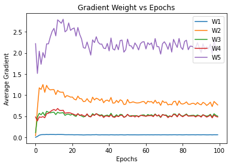

```python
# plot a line graph of the average gradient of the weights
ax = plt.subplot(1,1,1)
plt.plot(abs(fivelpnnAdaG.gradW1_all_avgs), label='W1')
plt.plot(abs(fivelpnnAdaG.gradW2_all_avgs), label='W2')
plt.plot(abs(fivelpnnAdaG.gradW3_all_avgs), label='W3')
plt.plot(abs(fivelpnnAdaG.gradW4_all_avgs), label='W4')
plt.plot(abs(fivelpnnAdaG.gradW5_all_avgs), label='W5')
plt.ylabel('Average Gradient')
plt.xlabel('Epochs')
plt.legend(loc='upper right')
plt.title('Gradient Weight vs Epochs')
plt.show()
```

## Implementing AdaM

```python
class FiveLayerPerceptronAdaM(object):
    def __init__(self, n_hidden1=30, n_hidden2=30, n_hidden3=30, n_hidden4 = 30,
                 C=0.0, epochs=500, eta=0.001, random_state=None,
                 alpha=0.1, beta=[0.0,0.0], decrease_const=0.0, shuffle=True, minibatches=1):
        np.random.seed(random_state)
        self.n_hidden1 = n_hidden1
        self.n_hidden2 = n_hidden2
        self.n_hidden3 = n_hidden3
        self.n_hidden4 = n_hidden4
        self.l2_C = C
        self.epochs = epochs
        self.eta = eta
        self.alpha = alpha
        self.beta = beta
        self.epsilon = 1e-8
        self.decrease_const = decrease_const
        self.shuffle = shuffle
        self.minibatches = minibatches

        self.gradW1_all_avgs = np.zeros(self.epochs)
        self.gradW2_all_avgs = np.zeros(self.epochs)
        self.gradW3_all_avgs = np.zeros(self.epochs)
        self.gradW4_all_avgs = np.zeros(self.epochs)
        self.gradW5_all_avgs = np.zeros(self.epochs)

    @staticmethod
    def _encode_labels(y):
        onehot = pd.get_dummies(y).values.T
        return onehot

    def _initialize_weights(self):
        glorot_factor1 = np.sqrt(6 / (self.n_features_ + self.n_hidden1))
        W1 = np.random.uniform(low=-glorot_factor1, high=glorot_factor1, size=(self.n_hidden1, self.n_features_))
        b1 = np.zeros((self.n_hidden1, 1))

        glorot_factor2 = np.sqrt(6 / (self.n_hidden1 + self.n_hidden2))
        W2 = np.random.uniform(low=-glorot_factor2, high=glorot_factor2, size=(self.n_hidden2, self.n_hidden1))
        b2 = np.zeros((self.n_hidden2, 1))

        glorot_factor3 = np.sqrt(6 / (self.n_hidden2 + self.n_hidden3))
        W3 = np.random.uniform(low=-glorot_factor3, high=glorot_factor3, size=(self.n_hidden3, self.n_hidden2))
        b3 = np.zeros((self.n_hidden3, 1))

        glorot_factor4 = np.sqrt(6 / (self.n_hidden3 + self.n_hidden4))
        W4 = np.random.uniform(low=-glorot_factor4, high=glorot_factor4, size=(self.n_hidden4, self.n_hidden3))
        b4 = np.zeros((self.n_hidden4, 1))

        glorot_factor5 = np.sqrt(6 / (self.n_hidden4 + self.n_output_))
        W5 = np.random.uniform(low=-glorot_factor5, high=glorot_factor5, size=(self.n_output_, self.n_hidden4))
        b5 = np.zeros((self.n_output_, 1))

        return W1, W2, W3, W4, W5, b1, b2, b3, b4, b5

    @staticmethod
    def _sigmoid(z):
        return expit(z)

    @staticmethod
    def _L2_reg(lambda_, W1, W2, W3, W4, W5):
        return (lambda_) * np.sqrt(np.mean(W1 ** 2) + np.mean(W2 ** 2) + np.mean(W3 ** 2) + np.mean(W4 ** 2) + np.mean(W5 ** 2))

    def _cost(self, A6, Y_enc, W1, W2, W3, W4, W5):
        cost = np.mean(-Y_enc * np.log(A6) - (1 - Y_enc) * np.log(1 - A6))
        L2_term = self._L2_reg(self.l2_C, W1, W2, W3, W4, W5)
        return cost + L2_term

    def _feedforward(self, X, W1, W2, W3, W4, W5, b1, b2, b3, b4, b5):
        A1 = X.T
        Z1 = W1 @ A1 + b1
        A2 = self._sigmoid(Z1)
        Z2 = W2 @ A2 + b2
        A3 = self._sigmoid(Z2)
        Z3 = W3 @ A3 + b3
        A4 = self._sigmoid(Z3)
        Z4 = W4 @ A4 + b4
        A5 = self._sigmoid(Z4)
        Z5 = W5 @ A5 + b5
        A6 = self._sigmoid(Z5)
        return A1, Z1, A2, Z2, A3, Z3, A4, Z4, A5, Z5, A6


    def _get_gradient(self, A1, A2, A3, A4, A5, A6, Z1, Z2, Z3, Z4, Z5, Y_enc, W1, W2, W3, W4, W5):
        V5 = (A6 - Y_enc)
        V4 = A5*(1-A5)*(W5.T @ V5)
        V3 = A4*(1-A4)*(W4.T @ V4)
        V2 = A3*(1-A3)*(W3.T @ V3)
        V1 = A2*(1-A2)*(W2.T @ V2)

        gradW5 = V5 @ A5.T
        gradW4 = V4 @ A4.T
        gradW3 = V3 @ A3.T
        gradW2 = V2 @ A2.T
        gradW1 = V1 @ A1.T

        gradb5 = np.sum(V5, axis=1).reshape(-1, 1)
        gradb4 = np.sum(V4, axis=1).reshape(-1, 1)
        gradb3 = np.sum(V3, axis=1).reshape(-1, 1)
        gradb2 = np.sum(V2, axis=1).reshape(-1, 1)
        gradb1 = np.sum(V1, axis=1).reshape(-1, 1)

        gradW1 += (self.l2_C * W1)
        gradW2 += (self.l2_C * W2)
        gradW3 += (self.l2_C * W3)
        gradW4 += (self.l2_C * W4)
        gradW5 += (self.l2_C * W5)

        return gradW1, gradW2, gradW3, gradW4, gradW5, gradb1, gradb2, gradb3, gradb4, gradb5


    def predict(self, X):
        _, _, _, _, _, _, _, _, _, _, A6 = self._feedforward(X, self.W1, self.W2, self.W3, self.W4, self.W5, self.b1, self.b2, self.b3, self.b4, self.b5)
        y_pred = np.argmax(A6, axis=0)
        return y_pred

    def fit(self, X, y, print_progress=0):
        """ Learn weights from training data."""
        X_data, y_data = X.copy(), y.copy()
        Y_enc = self._encode_labels(y)

        # init weights and setup matrices
        self.n_features_ = X_data.shape[1]
        self.n_output_ = Y_enc.shape[0]
        self.W1, self.W2, self.W3, self.W4, self.W5, self.b1, self.b2, self.b3, self.b4, self.b5 = self._initialize_weights()

        #initialize gradient matrices
        self.delta_W1_prev = np.zeros((self.epochs))
        self.delta_W2_prev = np.zeros((self.epochs))
        self.delta_W3_prev = np.zeros((self.epochs))
        self.delta_W4_prev = np.zeros((self.epochs))
        self.delta_W5_prev = np.zeros((self.epochs))

        # start momentum at zero for previous updates
        self.m_W1 = np.zeros(self.W1.shape) # for momentum
        self.m_W2 = np.zeros(self.W2.shape) # for momentum
        self.m_W3 = np.zeros(self.W3.shape) # for momentum
        self.m_W4 = np.zeros(self.W4.shape) # for momentum
        self.m_W5 = np.zeros(self.W5.shape) # for momentum
        self.v_W1 = np.zeros(self.W1.shape) # for momentum
        self.v_W2 = np.zeros(self.W2.shape) # for momentum
        self.v_W3 = np.zeros(self.W3.shape) # for momentum
        self.v_W4 = np.zeros(self.W4.shape) # for momentum
        self.v_W5 = np.zeros(self.W5.shape) # for momentum

        self.cost_ = []
        for k in range(self.epochs):

            #adaptive learning rate
            eta = self.eta**(1+self.decrease_const*k)# decreasing learning rate
            eta = max(eta,self.eta/1000)

            if print_progress>0 and (k+1)%print_progress==0:
                sys.stderr.write('\rEpoch: %d/%d' % (k+1, self.epochs))
                sys.stderr.flush()

            if self.shuffle:
                # shuffle the data so batches ar different
                ridx = np.random.permutation(y_data.shape[0])
                X_data, Y_enc = X_data[ridx], Y_enc[:, ridx]

            gradW1_avg = 0
            gradW2_avg = 0
            gradW3_avg = 0
            gradW4_avg = 0
            gradW5_avg = 0

            mini = np.array_split(range(y_data.shape[0]), self.minibatches)
            mini_cost = []
            for idx in mini:

                # feedforward
                A1, Z1, A2, Z2, A3, Z3, A4, Z4, A5, Z5, A6 = self._feedforward(X_data[idx], self.W1, self.W2, self.W3, self.W4, self.W5, self.b1, self.b2, self.b3, self.b4, self.b5)

                # compute cost
                cost = self._cost(A6, Y_enc[:, idx], self.W1, self.W2, self.W3, self.W4, self.W5)
                mini_cost.append(cost)

                # compute gradient via backpropagation
                gradW1, gradW2, gradW3, gradW4, gradW5, gradb1, gradb2, gradb3, gradb4, gradb5 = self._get_gradient(A1, A2, A3, A4, A5, A6, Z1, Z2, Z3, Z4, Z5, Y_enc[:, idx], self.W1, self.W2, self.W3, self.W4, self.W5)

                gradW1_t = np.mean(np.abs(gradW1))
                gradW1_avg = gradW1_avg + gradW1_t

                gradW2_t = np.mean(np.abs(gradW2))
                gradW2_avg = gradW2_avg + gradW2_t

                gradW3_t = np.mean(np.abs(gradW3))
                gradW3_avg = gradW3_avg + gradW3_t

                gradW4_t = np.mean(np.abs(gradW4))
                gradW4_avg = gradW4_avg + gradW4_t

                gradW5_t = np.mean(np.abs(gradW5))
                gradW5_avg = gradW5_avg + gradW5_t

                # momentum using AdaM algorithm

                #calculate aggregate of gradient
                self.m_W1 = self.beta[0]*self.m_W1 + (1-self.beta[0]) * gradW1
                self.m_W2 = self.beta[0]*self.m_W2 + (1-self.beta[0]) * gradW2
                self.m_W3 = self.beta[0]*self.m_W3 + (1-self.beta[0]) * gradW3
                self.m_W4 = self.beta[0]*self.m_W4 + (1-self.beta[0]) * gradW4
                self.m_W5 = self.beta[0]*self.m_W5 + (1-self.beta[0]) * gradW5

                #calcuate weights
                self.v_W1 = self.beta[1]*self.v_W1 + (1-self.beta[1]) * gradW1**2
                self.v_W2 = self.beta[1]*self.v_W2 + (1-self.beta[1]) * gradW2**2
                self.v_W3 = self.beta[1]*self.v_W3 + (1-self.beta[1]) * gradW3**2
                self.v_W4 = self.beta[1]*self.v_W4 + (1-self.beta[1]) * gradW4**2
                self.v_W5 = self.beta[1]*self.v_W5 + (1-self.beta[1]) * gradW5**2

                #calculate m_hat
                m_hat_W1 = self.m_W1/(1-self.beta[0]**(k+1))
                m_hat_W2 = self.m_W2/(1-self.beta[0]**(k+1))
                m_hat_W3 = self.m_W3/(1-self.beta[0]**(k+1))
                m_hat_W4 = self.m_W4/(1-self.beta[0]**(k+1))
                m_hat_W5 = self.m_W5/(1-self.beta[0]**(k+1))

                #calculate v_hat
                v_hat_W1 = self.v_W1/(1-self.beta[1]**(k+1))
                v_hat_W2 = self.v_W2/(1-self.beta[1]**(k+1))
                v_hat_W3 = self.v_W3/(1-self.beta[1]**(k+1))
                v_hat_W4 = self.v_W4/(1-self.beta[1]**(k+1))
                v_hat_W5 = self.v_W5/(1-self.beta[1]**(k+1))

                #update weights
                self.W1 -= eta * m_hat_W1/(np.sqrt(v_hat_W1) + self.epsilon)
                self.W2 -= eta * m_hat_W2/(np.sqrt(v_hat_W2) + self.epsilon)
                self.W3 -= eta * m_hat_W3/(np.sqrt(v_hat_W3) + self.epsilon)
                self.W4 -= eta * m_hat_W4/(np.sqrt(v_hat_W4) + self.epsilon)
                self.W5 -= eta * m_hat_W5/(np.sqrt(v_hat_W5) + self.epsilon)

                #update bias
                self.b1 -= eta * gradb1
                self.b2 -= eta * gradb2
                self.b3 -= eta * gradb3
                self.b4 -= eta * gradb4
                self.b5 -= eta * gradb5

            self.gradW1_all_avgs[k] = gradW1_avg/len(mini)
            self.gradW2_all_avgs[k] = gradW2_avg/len(mini)
            self.gradW3_all_avgs[k] = gradW3_avg/len(mini)
            self.gradW4_all_avgs[k] = gradW4_avg/len(mini)
            self.gradW5_all_avgs[k] = gradW5_avg/len(mini)

            self.cost_.append(np.mean(mini_cost))

        return self
```

```python
%%time
#run the FiveLayerRMSprop class
fivelpnnAdaM = FiveLayerPerceptronAdaM(n_hidden1 = 50, n_hidden2 = 50, n_hidden3 = 50, n_hidden4 = 50, C = 0.1, epochs = 100, eta = 0.01, alpha = 0.1, decrease_const = 0.1, minibatches = 50, shuffle = True, random_state = 1, beta = [0.2,0.2])
fivelpnnAdaM.fit(X_train_norm, y_train, print_progress=10)

yhat = fivelpnnAdaM.predict(X_test_norm)
print('Accuracy:',accuracy_score(y_test,yhat))
```

```
Epoch: 100/100
```

```
Accuracy: 0.7220159515951595
CPU times: user 6min 43s, sys: 5min 28s, total: 12min 11s
Wall time: 3min
```

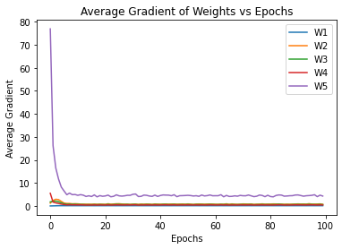

```python
# plot a line graph of the average gradient of the weights
ax = plt.subplot(1,1,1)
plt.plot(abs(fivelpnnAdaM.gradW1_all_avgs), label = 'W1')
plt.plot(abs(fivelpnnAdaM.gradW2_all_avgs), label = 'W2')
plt.plot(abs(fivelpnnAdaM.gradW3_all_avgs), label = 'W3')
plt.plot(abs(fivelpnnAdaM.gradW4_all_avgs), label = 'W4')
plt.plot(abs(fivelpnnAdaM.gradW5_all_avgs), label = 'W5')
plt.xlabel('Epochs')
plt.ylabel('Average Gradient')
plt.title('Average Gradient of Weights vs Epochs')
plt.legend()
plt.show()
```